# Storm data

maesh

2/3/2021

# Analysis for severe wather events that can cause both public health and economic problems

## Synopsis

Storms and other severe weather events can cause both public health and economic problems for communities and municipalities. Many severe events can result in fatalities, injuries, and property damage, and preventing such outcomes to the extent possible is a key concern.

In this report by using the U.S. National Oceanic and Atmospheric Administration’s (NOAA) storm database, I aim to describe which type of event causes the most severe effect on population health and property.

## Data processing

**Download raw data from web site**

```r
#Download file
setwd("C:/Users/maesh/Desktop/r for study/PeerReview_StormData")
url<-"https://d396qusza40orc.cloudfront.net/repdata%2Fdata%2FStormData.csv.bz2"
destfile<-"C:/Users/maesh/Desktop/r for study/PeerReview_StormData/StormData.csv.bz2"
download.file(url,destfile)

#read.csv.bz2 file
SData<-read.csv("StormData.csv.bz2")
```

**Processing data**

Then I processed the raw data into processed dataframe “data2”; required columns (i.e. “EVTYPE”,“FATALITIES”,“INJURIES”, “PROPDMG”, “REFNUM”) for analysis were subset

```r
#selet required column for analysis
#EVTYPE,FATALITIES,INJURIES,PROPDMG,REFNUM

library(dplyr)
data<-SData%>%select(EVTYPE,FATALITIES,INJURIES,PROPDMG,REFNUM)
```

Then the numbers of NAs in each column were confirmed

```r
#check NA in each column
pNA<-length(data$PROPDMG[is.na(data$PROPDMG)])
iNA<-length(data$INJURIES[is.na(data$INJURIES)])
fNA<-length(data$FATALITIES[is.na(data$FATALITIES)])

paste(pNA,iNA,fNA)
```

```
## [1] "0 0 0"
```

EVTYPEs are re-classified to 48 types (+“OTHERS”) of events and stored in new column “EVTYPE2”

```r
for (i in 1:length(data$EVTYPE)){
    if (data$EVTYPE[i]=="ASTRONOMICAL LOW TIDE"|data$EVTYPE[i]=="AVALANCHE"|
        data$EVTYPE[i]=="BLIZZARD"|data$EVTYPE[i]=="COASTAL FLOOD"|
        data$EVTYPE[i]=="COLD/WIND CHILL"|data$EVTYPE[i]=="DEBRIS FLOW"|
        data$EVTYPE[i]=="DENSE FOG"|data$EVTYPE[i]=="DENSE SMOKE"|
        data$EVTYPE[i]=="DROUGHT"|data$EVTYPE[i]=="DUST DEVIL"|
        data$EVTYPE[i]=="DUST STORM"|data$EVTYPE[i]=="EXCESSIVE HEAT"|
        data$EVTYPE[i]=="EXTREME COLD/WIND CHILL"|data$EVTYPE[i]=="FLASH FLOOD"|
        data$EVTYPE[i]=="FLOOD"|data$EVTYPE[i]=="FREEZING FOG"|
        data$EVTYPE[i]=="FROST/FREEZE"|data$EVTYPE[i]=="FUNNEL CLOUD"|
        data$EVTYPE[i]=="HAIL"|data$EVTYPE[i]=="HEAT"|data$EVTYPE[i]=="HEAVY RAIN"|
        data$EVTYPE[i]=="HEAVY SNOW"|data$EVTYPE[i]=="HIGH SURF"|
        data$EVTYPE[i]=="HIGH WIND"|data$EVTYPE[i]=="HURRICANE/TYPHOON"|
        data$EVTYPE[i]=="ICE STORM"|data$EVTYPE[i]=="LAKESHORE FLOOD"|
        data$EVTYPE[i]=="LAKE-EFFECT SNOW"|data$EVTYPE[i]=="LIGHTNING"|
        data$EVTYPE[i]=="MARINE HAIL"|data$EVTYPE[i]=="MARINE HIGH WIND"|data$EVTYPE[i]=="MARINE STRONG WIND"|
        data$EVTYPE[i]=="MARINE THUNDERSTORM WIND"|data$EVTYPE[i]=="RIP CURRENT"|
        data$EVTYPE[i]=="SEICHE"|data$EVTYPE[i]=="SLEET"|data$EVTYPE[i]=="STORM TIDE"|
        data$EVTYPE[i]=="STRONG WIND"|data$EVTYPE[i]=="THUNDERSTORM WIND"|
        data$EVTYPE[i]=="TORNADO"|data$EVTYPE[i]=="TROPICAL DEPRESSION"|data$EVTYPE[i]=="TROPICAL STORM"|data$EVTYPE[i]=="TSUNAMI"|data$EVTYPE[i]=="VOLCANIC ASH"|data$EVTYPE[i]=="WATERSPOUT"|data$EVTYPE[i]=="WILDFIRE"|data$EVTYPE[i]=="WINTER STORM"|data$EVTYPE[i]=="WINTER WEATHER"){data$EVTYPE2[i]<-data$EVTYPE[i]
    } else {data$EVTYPE2[i]<-"OTHERS"
    }
}

level_EVTYPE2<-c("ASTRONOMICAL LOW TIDE","AVALANCHE","BLIZZARD","COASTAL FLOOD","COLD/WIND CHILL","DEBRIS FLOW",
"DENSE FOG","DENSE SMOKE","DROUGHT","DUST DEVIL","DUST STORM",
"EXCESSIVE HEAT","EXTREME COLD/WIND CHILL","FLASH FLOOD","FLOOD",
"FREEZING FOG","FROST/FREEZE","FUNNEL CLOUD","HAIL","HEAT",
"HEAVY RAIN","HEAVY SNOW","HIGH SURF","HIGH WIND","HURRICANE/TYPHOON",
"ICE STORM","LAKESHORE FLOOD","LAKE-EFFECT SNOW","LIGHTNING",
"MARINE HAIL","MARINE HIGH WIND","MARINE STRONG WIND","MARINE THUNDERSTORM WIND",
"RIP CURRENT","SEICHE","SLEET","STORM TIDE","STRONG WIND",
"THUNDERSTORM WIND","TORNADO","TROPICAL DEPRESSION","TROPICAL STORM","TSUNAMI","VOLCANIC ASH","WATERSPOUT","WILDFIRE","WINTER STORM","WINTER WEATHER","OTHERS")

data2<-transform(data,EVTYPE2=factor(EVTYPE2,levels=level_EVTYPE2))
```

## Results

**Question 1**

Firstly I addressed the question “which types of events are most harmful with respect to population health?”

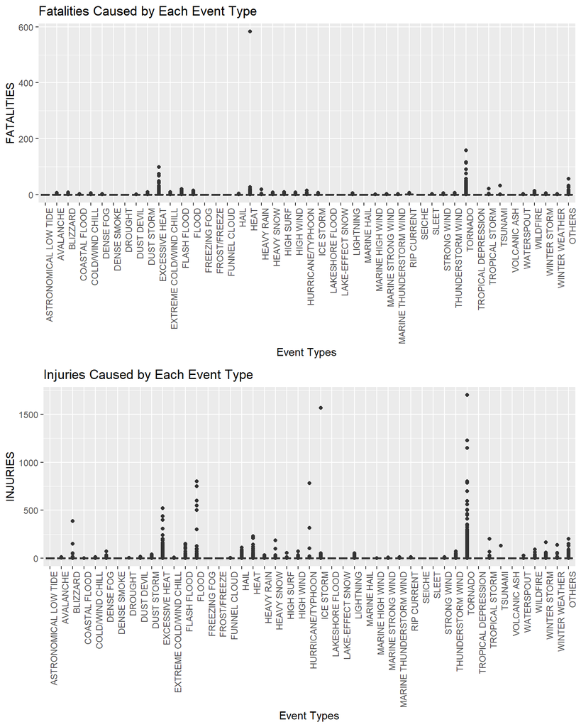

```r
library(ggplot2)
library(gridExtra)

#plot the relationships between event types and FATALITIES
fgraph<-ggplot(data=data2,aes(EVTYPE2,FATALITIES))+geom_boxplot()+theme(axis.text.x = element_text(angle = 90, hjust = 1))+
    labs(title="Fatalities Caused by Each Event Type", x="Event Types",y="FATALITIES")

#plot the relationships between event types and INJURIES

igraph<-ggplot(data=data2,aes(EVTYPE2,INJURIES))+geom_boxplot()+theme(axis.text.x = element_text(angle = 90, hjust = 1))+
    labs(title="Injuries Caused by Each Event Type", x="Event Types",y="INJURIES")

grid.arrange(fgraph,igraph,ncol=1)
```

As the graph shows, the median of each event types is nearly 0 . Then I focused on how is the total fatalities and injuries caused by each event type.

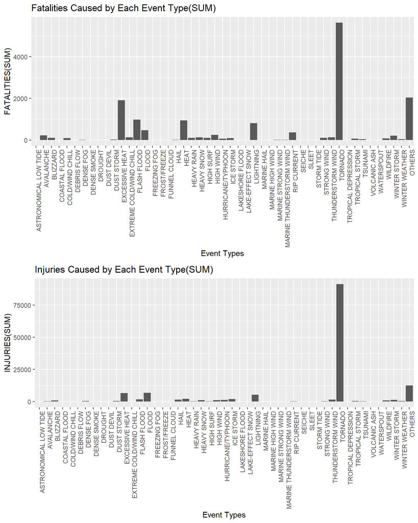

```r
fsum<-tapply(data2$FATALITIES,data2$EVTYPE2,sum)
isum<-tapply(data2$INJURIES,data2$EVTYPE2,sum)

fdata<-as.data.frame(fsum)
fdata$EVTYPE2<-rownames(fdata)
fdata2<-transform(fdata,EVTYPE2=factor(EVTYPE2,levels=level_EVTYPE2))

idata<-as.data.frame(isum)
idata$EVTYPE2<-rownames(idata)
idata2<-transform(idata,EVTYPE2=factor(EVTYPE2,levels=level_EVTYPE2))

fsumgraph<-ggplot(data=fdata2,aes(EVTYPE2,fsum))+geom_bar(stat="identity")+theme(axis.text.x = element_text(angle = 90, hjust = 1))+
    labs(title="Fatalities Caused by Each Event Type(SUM)", x="Event Types",y="FATALITIES(SUM)")

isumgraph<-ggplot(data=idata2,aes(EVTYPE2,isum))+geom_bar(stat="identity")+theme(axis.text.x = element_text(angle = 90, hjust = 1))+
    labs(title="Injuries Caused by Each Event Type(SUM)", x="Event Types",y="INJURIES(SUM)")

grid.arrange(fsumgraph,isumgraph,ncol=1)
```

As the graph shows, Tornado has the biggest impact on public populations in last 60 years.

**Question 2**

Across the United States, which types of events have the greatest economic consequences?

To answer this question I focused on the median and the sum of property damage caused by each event type.

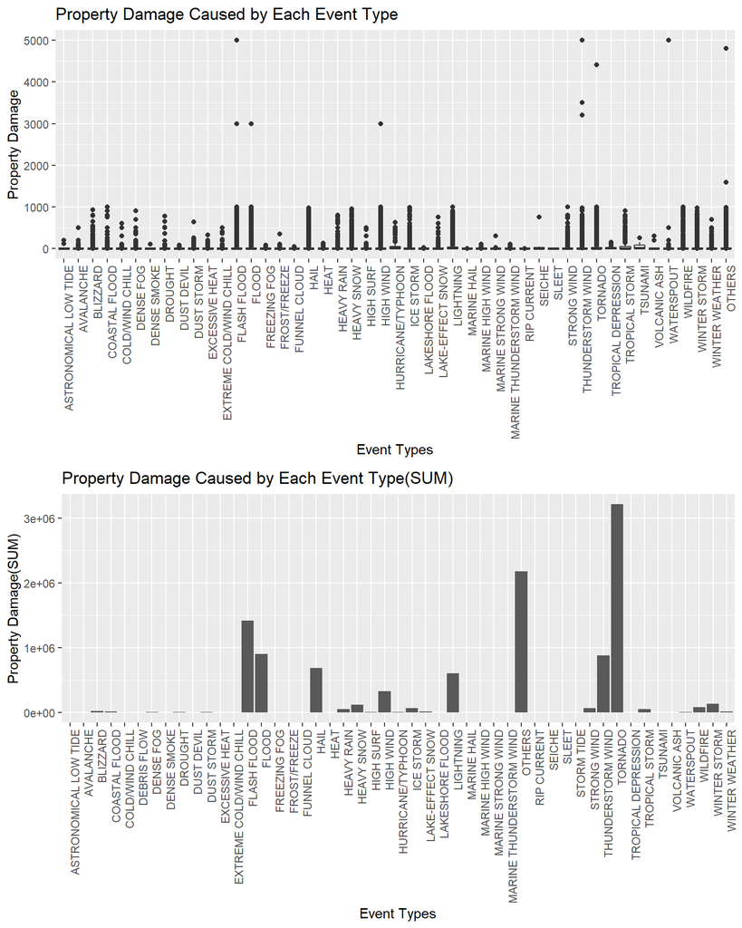

```r
#plot the relationships between event types and property damage
pgraph<-ggplot(data=data2,aes(EVTYPE2,PROPDMG))+geom_boxplot()+theme(axis.text.x = element_text(angle = 90, hjust = 1))+
    labs(title="Property Damage Caused by Each Event Type", x="Event Types",y="Property Damage")

psum<-tapply(data2$PROPDMG,data2$EVTYPE2,sum)

pdata<-as.data.frame(psum)
pdata$EVTYPE2<-rownames(pdata)

psumgraph<-ggplot(data=pdata,aes(EVTYPE2,psum))+geom_bar(stat="identity")+theme(axis.text.x = element_text(angle = 90, hjust = 1))+
    labs(title="Property Damage Caused by Each Event Type(SUM)", x="Event Types",y="Property Damage(SUM)")


grid.arrange(pgraph,psumgraph,ncol=1)
```

As the graph shows, the median of property damage were almost 0, but the sum of property damage was the biggest in Tornado.